# Youtube Project

Author

Nicholas Fisher

#### This is for my practice in R programming skills. I am interested in the effect of removing dislikes from Youtube. My dataset I will be using comes from here:

https://www.kaggle.com/datasets/datasnaek/youtube-new?select=USvideos.csv.

## Part 1: Download package and CSV File

```r
#Install package dplyr
library(dplyr)
library(knitr)
library(gtsummary)
library(ggplot2)
library(lubridate)
#Download the CSV file from Kaggle
yt_data <- read.csv("USvideos.csv", string = FALSE)

#check dimensions
dim(yt_data)
```

```
[1] 40949    16
```

There are 40949 rows in the dataset and 16 variables.

```r
#Review column names
colnames(yt_data)
```

```
 [1] "video_id"               "trending_date"          "title"
 [4] "channel_title"          "category_id"            "publish_time"
 [7] "tags"                   "views"                  "likes"
[10] "dislikes"               "comment_count"          "thumbnail_link"
[13] "comments_disabled"      "ratings_disabled"       "video_error_or_removed"
[16] "description"
```

## Part 2: Data Cleaning

#### - Remove unnecessary columns as well as omitting data with NaN values.

```r
#removing unnecessary columns
yt_data$video_id <- NULL
yt_data$tags <- NULL
yt_data$trending_date <- NULL
yt_data$thumbnail_link <- NULL
yt_data$description <- NULL
yt_data$video_error_or_removed <- NULL
yt_data$category_id <- NULL

#removes rows where NA values exist
yt_data <- na.omit(yt_data)
```

```r
#Check rows
nrow(yt_data)
```

```
[1] 40949
```

Dataset has 40949 rows.

#### - Next part in the cleaning process is removing duplicate rows and rows where comments and likes are disabled. As well as adding my own columns in helpful for the analysis.

```r
#remove data where the row is repeated
ct_data <- yt_data[!duplicated(yt_data
                               [ ,c("title","publish_time", "channel_title")]), ]


#removes data that where like and dislike data is disabled.
yt_data1 <- ct_data$ratings_disabled == "False"
ct_data1 <- ct_data[yt_data1, ]

#removes data where comments are disabled.
ct_data2 <- ct_data1$comments_disabled == "False"
bt_data <- ct_data1[ct_data2, ]

#resets the row indices
rownames(bt_data) <- NULL

#remove columns
bt_data$comments_disabled <- NULL
bt_data$ratings_disabled <- NULL

#change dislikes from 0 to 1 so no NaN values
bt_data$dislikes[bt_data$dislikes == 0] <- 1

#change comment_count from 0 to 1 so no NaN values
bt_data$comment_count[bt_data$comment_count == 0] <- 1

#change likes from 0 to 1 so no NaN values
bt_data$likes[bt_data$likes == 0] <- 1

#adds column interaction to show likes to views
bt_data$interaction <- round(bt_data$likes/ bt_data$views, 6)

#adds column likes_diff and shows the difference of likes to dislikes
bt_data$likes_diff<- bt_data$likes - bt_data$dislikes

#Add column dislike ratio
bt_data$dislike_ratio <- bt_data$dislikes/(bt_data$likes + bt_data$dislikes)

#reordering data based on interaction
bt_data <- bt_data[order(-bt_data$interaction), ]
rownames(bt_data) <- NULL
```

#### Completed: Cleaned data renamed bt_data where I can start to analyze it

```r
dim(bt_data)
```

```
[1] 6354   10
```

## Part 3 Data Analysis

#### Challenge 1: Seeing if the amount of likes is a enough to determine if a video is of quality or not.

```r
df_low_int <- bt_data|>
  dplyr::select(title, channel_title, views, likes, dislikes, interaction)|>
  slice_tail(n = 6)

kable(df_low_int, format = "html")
```

| title | channel_title | views | likes | dislikes | interaction |
| --- | --- | --- | --- | --- | --- |
| Ref to the Rescue \| 2018 Kona \| Hyundai NFL Super Bowl LII | HyundaiUSA | 523481 | 100 | 13 | 0.000191 |
| Michael Wolff, “Fire and Fury \| theSkimm Sip 'n Skimm | theSkimm | 11216 | 2 | 14 | 0.000178 |
| Did Alexa Lose Her Voice? - Teaser - Amazon Super Bowl Commercial LII | amazon | 4683106 | 763 | 60 | 0.000163 |
| LuLaRoe Consultant Mocks Those With Special Needs | J S | 212858 | 27 | 591 | 0.000127 |
| THE SHAPE OF WATER \| Human \| FOX Searchlight | FoxSearchlight | 349383 | 38 | 2 | 0.000109 |
| The Path Season 3 Trailer (Official) • The Path on Hulu | Hulu | 2159497 | 162 | 12 | 0.000075 |

These videos have the lowest interaction, meaning they have the least amount of likes to number of views. So does that mean these videos are disliked? Not necessarily, these videos display the dislikes as well and it can be seen that 4 out of the 6 top interaction videos have more likes to dislikes (view likes_diff). Meaning that just a low number of likes does not infer the video disliked.

#### Challenge 2: What is the most disliked video in the dataset and what does it mean?

```r
the_worst <- min(bt_data$likes_diff)
worse <- which(bt_data$likes_diff == the_worst)
kable(bt_data[worse, ], format = "html")
```

|  | title | channel_title | publish_time | views | likes | dislikes | comment_count | interaction | likes_diff | dislike_ratio |
| --- | --- | --- | --- | --- | --- | --- | --- | --- | --- | --- |
| 5569 | PSA from Chairman of the FCC Ajit Pai | Daily Caller | 2017-12-13T22:52:57.000Z | 1142585 | 9100 | 218841 | 28013 | 0.007964 | -209741 | 0.9600774 |

This is the most dislikes to likes video from the dataset. “PSA from Chairman of the FCC Ajit Pai” I find it helpful to know the dislike count because I would not have known this guy was actually someone who was disliked to the public. It could have just been a video about a middle aged guy making a joke online. But there is something much deeper to this video.

## Part 4 Deeper Dive into YouTube Dislikes

#### Research Question: Which year received the most proportion of dislikes according to this dataset?

```r
#Create table of videos in each year
dt  <- ymd_hms(bt_data$publish_time, tz = "UTC")   # parse as UTC
yr  <- year(with_tz(dt, "UTC"))                    # take year in UTC
table(yr)
```

```
yr
2006 2008 2009 2010 2011 2012 2013 2014 2015 2016 2017 2018
   1    3    5    6    8    8   13    7    9    8 2147 4139
```

It can be seen the years 2006 - 2016 have less videos than 2017 and 2018. Making it better to group them and compare groups.

```r
# <2017

bt_2016under <- bt_data|>
  filter( publish_time < "2017-01-01")

# 2017
bt_2017 <- bt_data|>
  filter(publish_time >= "2017-01-01" & publish_time < "2018-01-01")

# 2018
bt_2018 <- bt_data|>
  filter(publish_time >= "2018-01-01")
```

#### Created a separate data frame for each time frame. 2006 - 2016, 2017, and 2018 are my groups of interest.

```r
#2006-2016 dataset
bt_2016under <- bt_data|>
  filter( publish_time < "2017-01-01")

#2017 dataset
bt_2017 <- bt_data|>
  filter(publish_time >= "2017-01-01" & publish_time < "2018-01-01")

#2018 dataset
bt_2018 <- bt_data|>
  filter(publish_time >= "2018-01-01")


avg_dislike_2016under<- round(mean(bt_2016under$dislike_ratio), 4)
avg_dislike_2017 <- round(mean(bt_2017$dislike_ratio), 4)
avg_dislike_2018 <- round(mean(bt_2018$dislike_ratio), 4)

sd_dislike_2016under <- round(sd(bt_2016under$dislike_ratio), 4)
sd_dislike_2017 <- round(sd(bt_2017$dislike_ratio), 4)
sd_dislike_2018 <- round(sd(bt_2018$dislike_ratio), 4)

avg_dislike_prop <- data.frame(c("2016 & before","2017","2018"),
                               c(avg_dislike_2016under, avg_dislike_2017,
                                 avg_dislike_2018),
                               c(sd_dislike_2016under, sd_dislike_2017,
                                 sd_dislike_2018))

colnames(avg_dislike_prop) <- c("Year", "ADP", "SD of Dislike Proportion")

avg_dislike_prop$ADP <- paste0(avg_dislike_prop$ADP*100, " %")

colnames(avg_dislike_prop) <- c("Year", "Avg. Dislike Percentage",
                                "SD of Dislike Proportion")

avg_dislike_prop
```

```
           Year Avg. Dislike Percentage SD of Dislike Proportion
1 2016 & before                 10.95 %                   0.1552
2          2017                  7.09 %                   0.1103
3          2018                  6.31 %                   0.1008
```

So according this table it can be seen the highest average of dislikes for the videos with dislikes is 2016 & before. If that is the case, and the trend of dislikes is decreasing, it could be said there are less people to share negative feedback over videos as time progresses. So why cancel the viewership for those who still like to share negative feedback?

#### Lastly I will be making a 95% Confidence Interval for the True mean of dislikes proportion from beginning of 2017 to end of 2018.

```r
btci <- bt_data |>
  filter(publish_time >= "2017-01-01")
n <- nrow(btci)
p_hat <- mean(btci$dislike_ratio)
p_hat
```

```
[1] 0.06577307
```

##### Step 1 State my Parameter

I am looking for the interval where $P$ ~ the true proportion of dislikes for a video in the years 2017 and 2018 combined.

##### Step 2 Check Conditions

I assume independence because these videos were uploaded by individuals who do not hold relation with each other. As well the host of the Kaggle document said he was able to grab these observations from the Youtube API an unbiased datasource.

```r
n*p_hat >= 10
```

```
[1] TRUE
```

```r
n*(1-p_hat) >= 10
```

```
[1] TRUE
```

Also want to check normality of the dislike ratio.

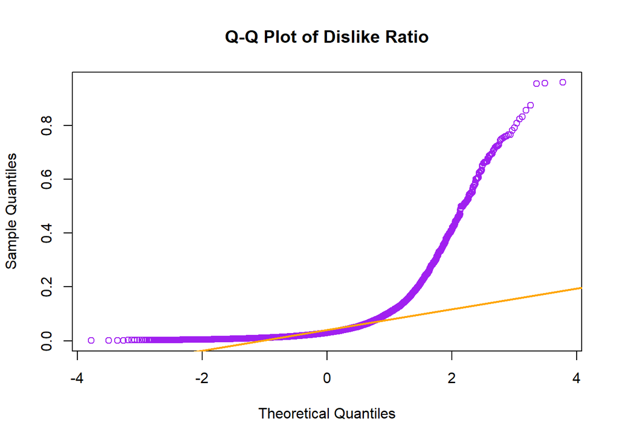

```r
qqnorm(btci$dislike_ratio, main = "Q-Q Plot of Dislike Ratio", col = "purple")
qqline(btci$dislike_ratio, col = "orange", lwd = 2)
```

So, it turns out the data is pretty skewed. I am going to be using a bootstrap method to complete this confidence interval.

##### Boot Strap my data.

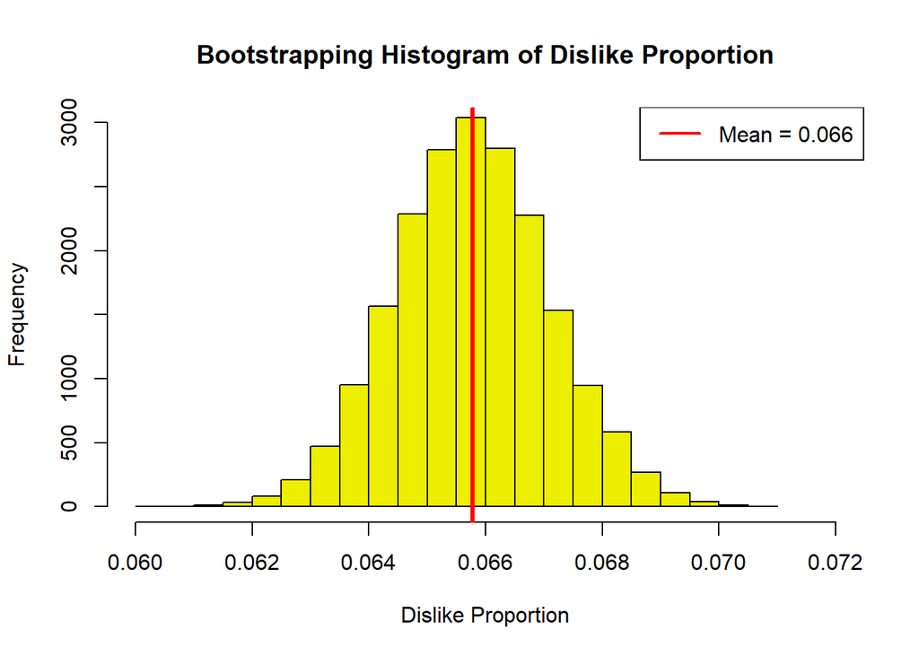

```r
#Since sample size is 6286 I want to make sure I cover all replications.
B <- 20000
dis_boot <- rep(NA, B)

#creating the variable disboot to hold my random sample means
set.seed(14204999)
for (i in 1:B){
  dislike <- sample(btci$dislike_ratio, n, replace = TRUE)
  dis_boot[i] <- mean(dislike)
}

#Average mean of the Boot distribution
boot_p <- mean(dis_boot)

#Histogram of Boot Distribution
hist(dis_boot, main = "Bootstrapping Histogram of Dislike Proportion",
     col = "yellow2", xlab = "Dislike Proportion", xlim = c(.060, .072), ylim = c(0, 3000))
abline(v = boot_p, col = "red", lwd = 3)
legend("topright",
       legend = paste("Mean =", round(mean(boot_p), 3)),
       col = "red",
       lwd = 2,
       bty = "o")
```

#### I will now conduct the confidence interval with the bootstrap values.

```r
#Confidence interval
dis_boot_df <- data.frame(dis_boot)

dis_boot_df |>
  summarize(lower = round(quantile(dis_boot, .025), 3),
            upper = round(quantile(dis_boot, .975), 3))
```

```
  lower upper
1 0.063 0.068
```

So we are 95% confident that the true proportion of dislikes per video in 2017 to 2018, was between 6.3% to 6.8%. Pretty small amount of dislikes in each video to be frank. Either the video quality is just that good, or viewers do not abuse the dislike button. It could either.

## Conclusion

I hope I was able to convey some ideas about the nature of dislikes in a video and help shape a feeling about whether YouTube dislikes should be back or if they should not. I added a link as well to explain how to view dislikes on YouTube from a third party company. Take care till next time.

https://www.youtube.com/watch?v=cUVGjT8szhQ&t=16s